# Banana project, organic matter-microbiome

2023-10-18

# Analisis de datos octubre 2023

## Propidedades del suelo

Esto se ha hecho para cargar el Excel de los datos iniciales (ojo, para poner el directorio de donde esta tu archivo excel, se tiene que cambiar , por /), y para hacer la media de cada tratamiento, ya que de cada tratamiento hay 3 repeticiones. El simbolo %>% se llaman tuberias (the pipe) vienen de la libreria (tinyverse) (esta libreria sirve para mantener R más ordenado). Las tuberias funcionan usando el resultado de una operación(out) y convirtiendolo en el imput de otra. En el caso del codigo “soil.summ <- soil_prop %>% group_by(treatment, time) %>% summarise(across(.cols=everything(), .fns=mean),.groups =”drop”)” quiere decir lo siguiente: hemos creado un objeto nuevo que es soil.summ, que es_ el archivo de excel soil_prop el que hacemos una serie de operaciones en cadena (tuberia) donde agrupamos solamente por tratamiento y tiempo (group_by,) y en ese agrupamiento queremos de todas las columnas, .cols=every, que haga la funcion de la media (fns=mean). NULL significa que no tenga en cuenta esas columnas. $ es para seleccionar cosas especificas.

### Evolucion de cada parametros en los distintos muestreos del experimento

En este codigo veremos la evolucion de los distintos parametros en el tiempo. La función “aes” sirve para indicar en un grafico cual es tu X,y. Debes indicar en texto quien es quien.Toda la información de los datos referido al grafico es lo que va dentro del parentesis. Los adornos van fuera con el signo de +. La funcion “geom_line” sirve para elegir el tipo de grafico que quieres.

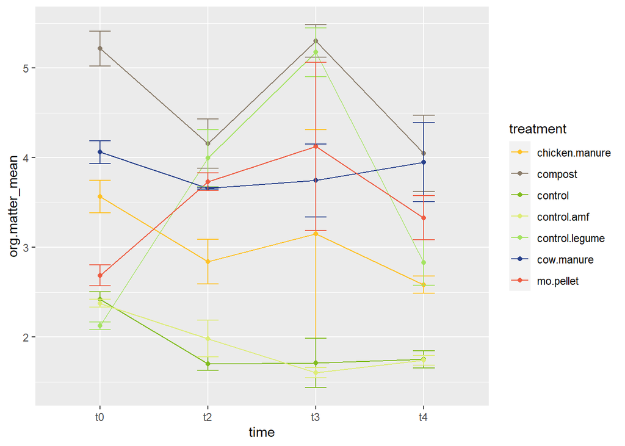

```r
org.mat.plotsd <- soil.summ.sd%>% ggplot(aes(x=time, group= treatment, col= treatment, y= org.matter_mean))+
  geom_line()+
  scale_colour_banana_disc("paleta.treat")+
  geom_point()+
  geom_errorbar(aes(ymin=org.matter_mean-org.matter_sd, ymax=org.matter_mean+org.matter_sd), width=0.2)
org.mat.plotsd
```

[Figure 1: organic matter over time in diffrerent treatments.]

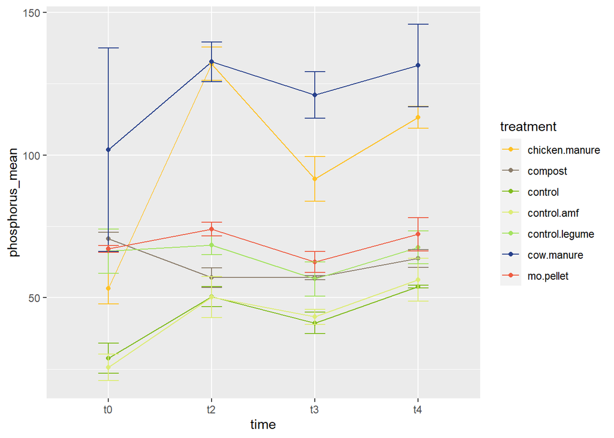

[Figure 2: phosphorous over time in different treatments.]

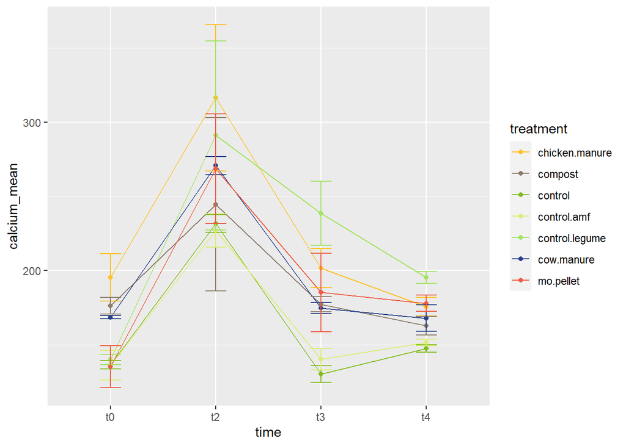

[Figure 3. calcium over time in different treatments.]

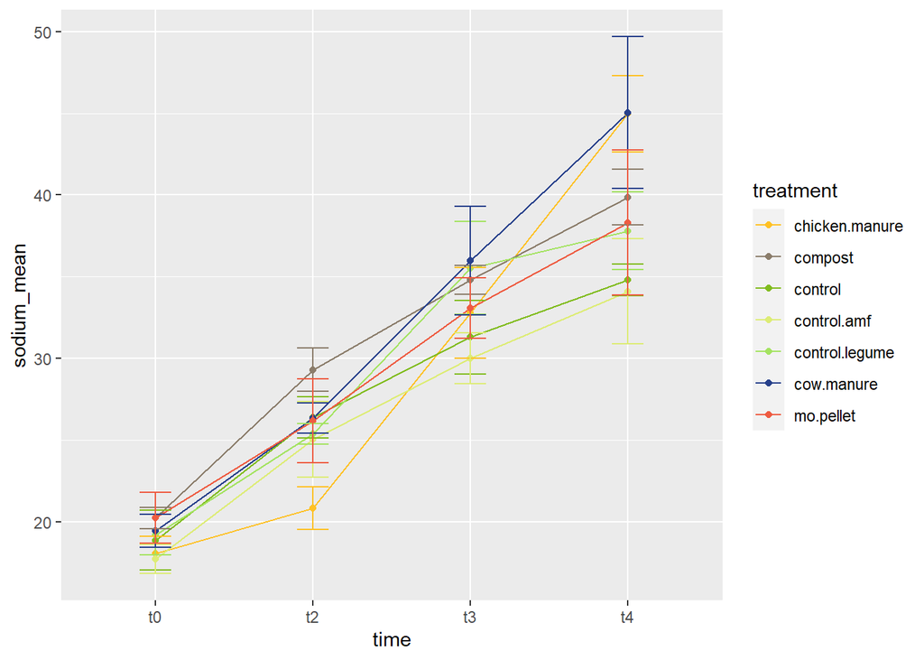

[Figure 4: sodium over time in different treatments.]

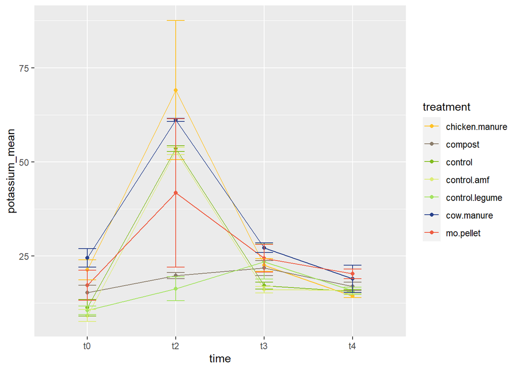

[Figure 5: potassium over time in different treatments.]

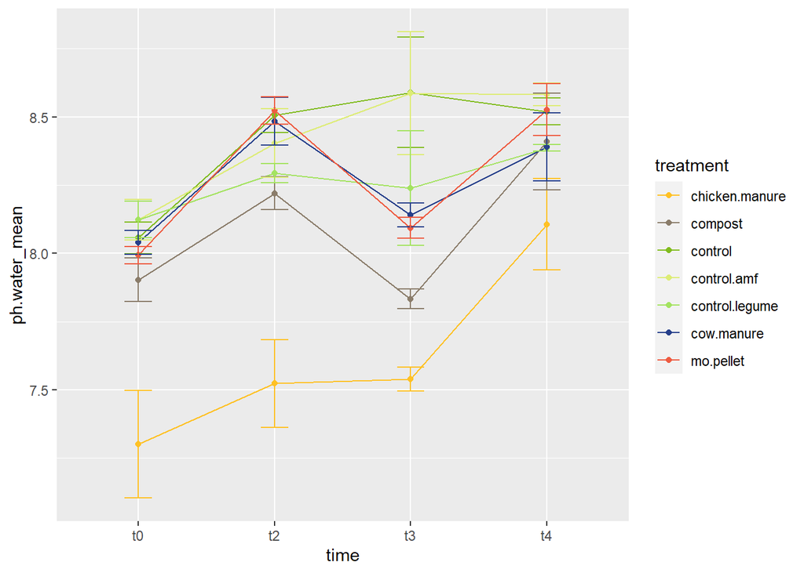

[Figure 6: pH water over time in different treatments.]

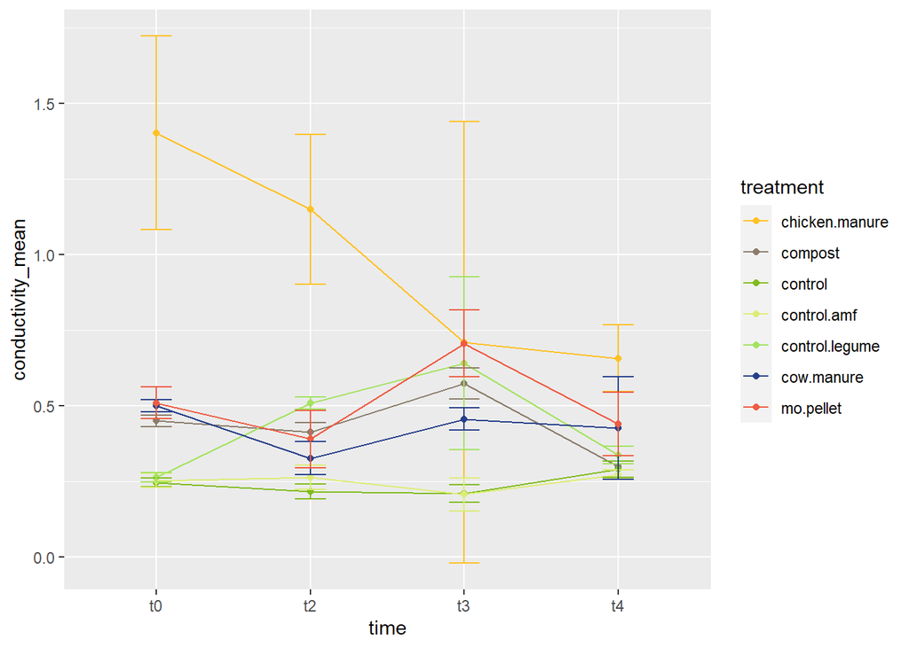

[Figure 7: conductivity over time in different treatments.]

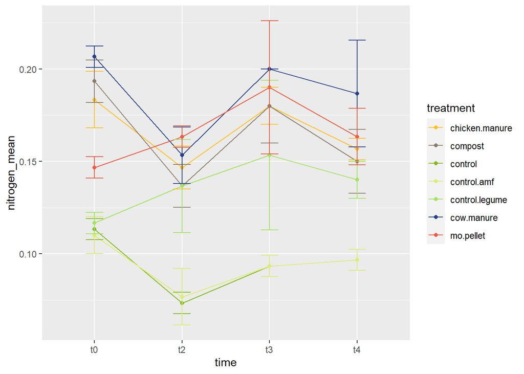

[Figure 8: nitrogen over time in different treatments.]